# Visit Reports

David Simons

The Royal Veterinary College, London, UK

2021-10-04

Five villages have been enrolled, one will not be carried forward due to concerns from the local team. The village are:

- Bambawo (coordinates 8.009 N, -11.1303 E)
  - Visit 1 - 2021-06-23 to 2021-06-27
  - Visit 2 - 2021-10
- Lalehun (coordinates 8.1975 N, -11.0803 E)
  - Visit 1 - 2020-11-30 to 2020-12-03
  - Visit 2 - 2021-04-01 to 2021-04-04
  - Visit 3 - 2021-07-08 to 2021-07-12
  - Visit 4 - 2021-10
- Lambayama (coordinates 7.8544 N, -11.1897 E)
  - Visit 1 - 2021-06-28 to 2021-07-02
  - Visit 2 - 2021-10
- Seilama (coordinates 8.1222 N, -11.1936 E)
  - Visit 1 - 2020-12-05 to 2020-12-09
  - Visit 2 - 2021-04-12 to 2021-04-15
  - Visit 3 - 2021-07-13 to 2021-07-17
  - Visit 4 - 2021-10
- Baiama (coordinates 7.83708 N, -11.26845 E)
  - Visit 1 - 2021-07-03 to 2021-07-07
  - Visit 2 - 2021-10

Rodents are trapped at up to 6 distinct trap sites per village with up to 49 traps per site. Data is collected on this group of [data collection forms](https://drive.google.com/drive/folders/1yE_JAThq-DM9y5yvtSPMgM2ezMcZ_zyO?usp=sharing) or on the digitised versions using electronic pads in the field using [ODK](https://opendatakit.lshtm.ac.uk/lshtm-odk-servers/) all digital forms are encrypted locally on the device and sent to a server based at LSHTM. The `.xlsx` versions of the ODK forms are available on the OpenScience Framework [project page](https://osf.io/usjrd/).

We have currently obtained 7,270 trap nights across 3 visits (including the pilot).

There will ideally be study visits 4 times per year (every 3 months), dates will be confirmed with the study team.

The land use predominantly obtained from Jung et al. and ground truthed through discussion with local communities guided the selection of the trapping sites at study villages.

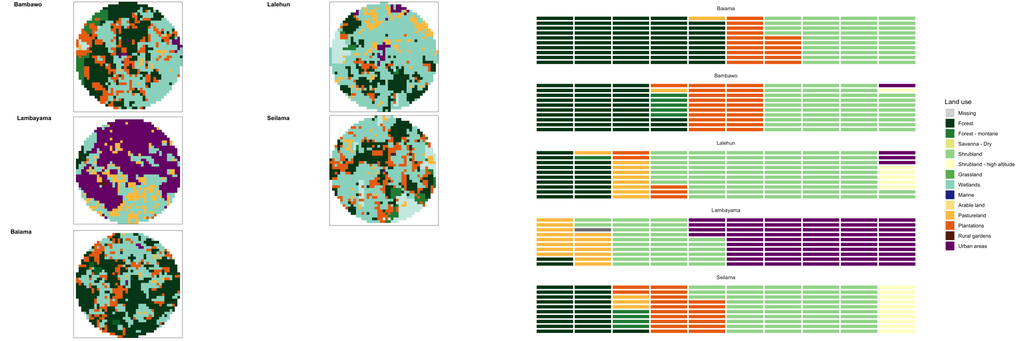

The trap locations are shown overlayed on these habitat maps below.

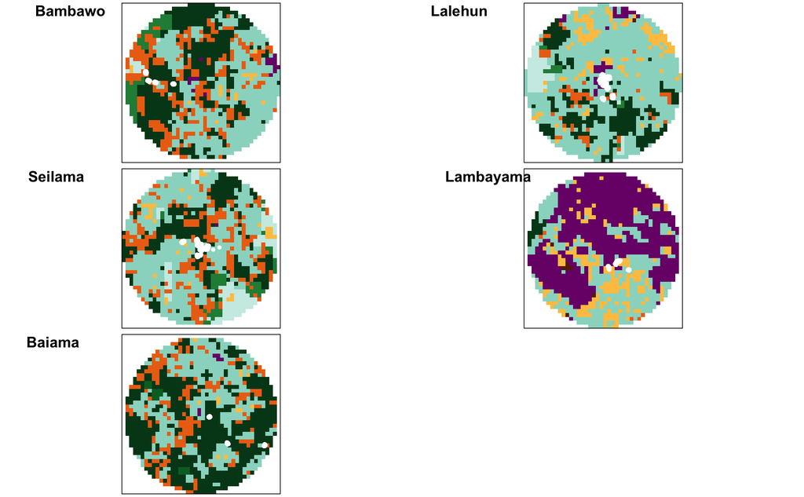

The proportion of nights trapping in each habitat gave good coverage of land use types in Eastern Sierra Leone.

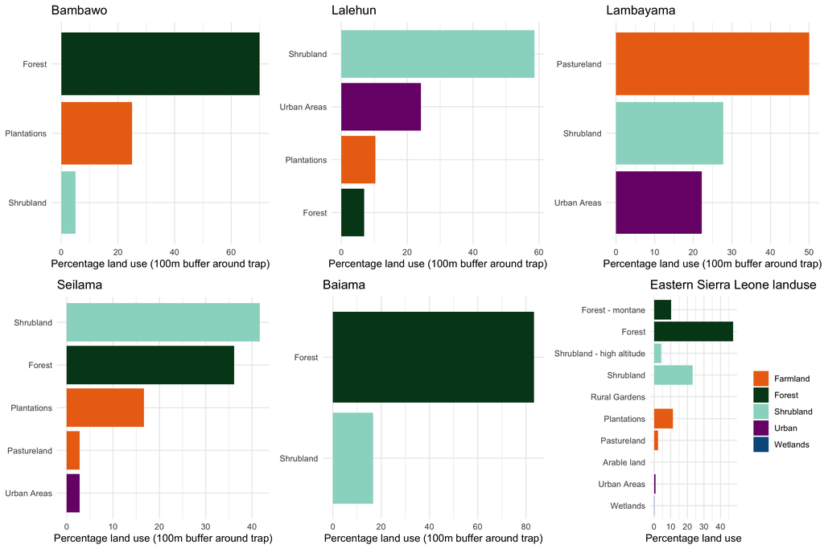

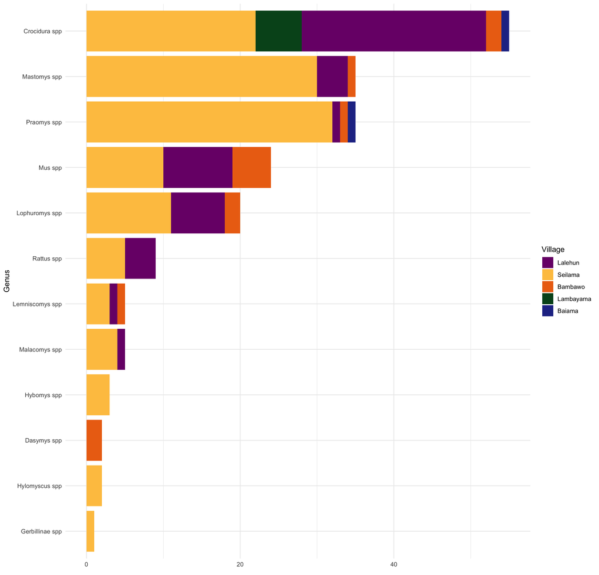

Species accumulation curves have been produced for the first two visits from Lalehun and Seilama. It has not been possible to produce equivalent plots for Baiama and Lambayama due to the low number of individuals/species trapped in those locations.

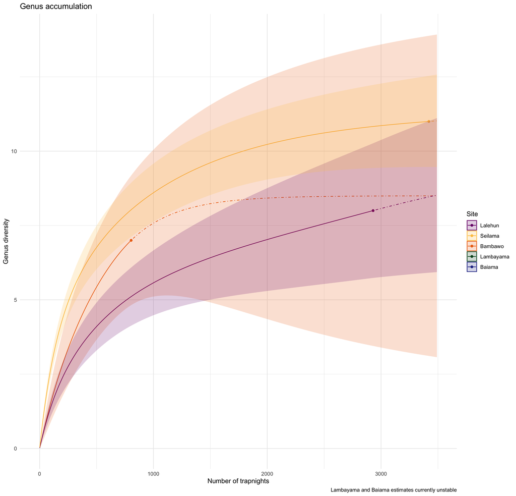

As we catch an increasing number of individuals we are seeing them clustering within expected habitats.

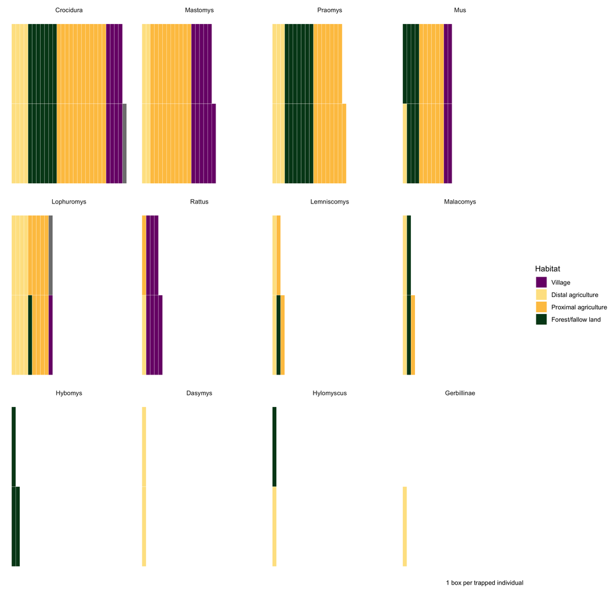